# Statistical Learning Project

```r
my_data$MaritalStatus[is.na(my_data$MaritalStatus)] = "NeverMarried"
summary(my_data)
```

```
##     Gender          Race1           Age             MaritalStatus
##  female:2900   Black   : 865   Min.   : 8.00   Divorced    : 437
##  male  :2811   Hispanic: 407   1st Qu.:23.00   LivePartner : 369
##                Mexican : 687   Median :39.00   Married     :2434
##                White   :3251   Mean   :40.85   NeverMarried:2006
##                Other   : 501   3rd Qu.:57.00   Separated   : 134
##                                Max.   :80.00   Widowed     : 331
##
##         HHIncome        Weight           Height           BMI
##  more 99999 :1131   Min.   : 21.70   Min.   :119.1   Min.   :12.90
##  75000-99999: 574   1st Qu.: 62.10   1st Qu.:159.1   1st Qu.:22.80
##  25000-34999: 568   Median : 75.80   Median :166.9   Median :26.75
##  35000-44999: 514   Mean   : 77.51   Mean   :166.4   Mean   :27.69
##  45000-54999: 435   3rd Qu.: 90.50   3rd Qu.:174.8   3rd Qu.:31.40
##  (Other)    :2009   Max.   :230.70   Max.   :200.4   Max.   :81.25
##  NA's       : 480   NA's   :28       NA's   :28      NA's   :33
##     BMICatUnder20yrs   DirectChol       TotChol           Pulse
##  UnderWeight:  24    Min.   :0.390   Min.   : 1.530   Min.   : 40.00
##  NormWeight : 338    1st Qu.:1.090   1st Qu.: 4.090   1st Qu.: 64.00
##  OverWeight :  91    Median :1.290   Median : 4.780   Median : 72.00
##  Obese      : 113    Mean   :1.356   Mean   : 4.864   Mean   : 73.54
##  NA's       :5145    3rd Qu.:1.580   3rd Qu.: 5.510   3rd Qu.: 82.00
##                      Max.   :4.030   Max.   :13.650   Max.   :136.00
##                      NA's   :321     NA's   :321      NA's   :156
##     BPSysAve        BPDiaAve        UrineVol1       UrineFlow1      PhysActive
##  Min.   : 76.0   Min.   :  0.00   Min.   :  0.0   Min.   : 0.0000   No  :2439
##  1st Qu.:106.0   1st Qu.: 60.00   1st Qu.: 50.0   1st Qu.: 0.4040   Yes :2919
##  Median :116.0   Median : 68.00   Median : 93.0   Median : 0.6910   NA's: 353
##  Mean   :118.2   Mean   : 66.87   Mean   :118.9   Mean   : 0.9686
##  3rd Qu.:127.0   3rd Qu.: 76.00   3rd Qu.:165.0   3rd Qu.: 1.2140
##  Max.   :226.0   Max.   :116.00   Max.   :510.0   Max.   :17.1670
##  NA's   :164     NA's   :164      NA's   :51      NA's   :400
##  SleepHrsNight    Diabetes
##  Min.   : 2.000   No :5163
##  1st Qu.: 6.000   Yes: 548
##  Median : 7.000
##  Mean   : 6.912
##  3rd Qu.: 8.000
##  Max.   :12.000
##  NA's   :747
```

To fix the NA values in HHIncome we will find the mode and use it to fill these null cells.

```r
levels(my_data$HHIncome)
```

```
##  [1] " 0-4999"     " 5000-9999"  "10000-14999" "15000-19999" "20000-24999"
##  [6] "25000-34999" "35000-44999" "45000-54999" "55000-64999" "65000-74999"
## [11] "75000-99999" "more 99999"
```

```r
my_data <- my_data %>%
  mutate(HHIncome = case_when(
    HHIncome %in% c("0-4999", "5000-9999", "10000-14999", "15000-19999") ~ "Low Income",
    HHIncome %in% c("20000-24999", "25000-34999","35000-44999", "45000-54999") ~ "Middle Income",
    HHIncome %in% c("55000-64999", "65000-74999", "75000-99999", "more 99999") ~ "High Income"
  ))

my_data$HHIncome <- factor(my_data$HHIncome)
mode_income <- names(sort(table(my_data$HHIncome), decreasing = TRUE))[1]
my_data$HHIncome[is.na(my_data$HHIncome)] <- mode_income
```

To fix the missing values for weight and height we will look for the age of each person and find the average weight/height for this age range and put that as our new value. The missing BMI values will be calculated based on the added weight and height.

```r
my_data <- my_data %>%
  mutate(AgeGroup = cut(Age, breaks = seq(0, max(Age, na.rm = TRUE), by = 2), include.lowest = TRUE)) %>%
  group_by(AgeGroup) %>%
  mutate(
    Weight = ifelse(is.na(Weight), mean(Weight, na.rm = TRUE), Weight),
    Height = ifelse(is.na(Height), mean(Height, na.rm = TRUE), Height)
  ) %>%
  ungroup()
my_data = my_data %>% dplyr::select(-AgeGroup)
my_data$BMI[is.na(my_data$BMI)] <- my_data$Weight[is.na(my_data$BMI)] / (my_data$Height[is.na(my_data$BMI)]^2)
summary(my_data)
```

```
##     Gender          Race1           Age             MaritalStatus
##  female:2900   Black   : 865   Min.   : 8.00   Divorced    : 437
##  male  :2811   Hispanic: 407   1st Qu.:23.00   LivePartner : 369
##                Mexican : 687   Median :39.00   Married     :2434
##                White   :3251   Mean   :40.85   NeverMarried:2006
##                Other   : 501   3rd Qu.:57.00   Separated   : 134
##                                Max.   :80.00   Widowed     : 331
##
##           HHIncome        Weight           Height           BMI
##  High Income  :3102   Min.   : 21.70   Min.   :119.1   Min.   : 0.00146
##  Low Income   : 704   1st Qu.: 62.20   1st Qu.:159.2   1st Qu.:22.71000
##  Middle Income:1905   Median : 75.80   Median :166.9   Median :26.70000
##                       Mean   : 77.52   Mean   :166.4   Mean   :27.53479
##                       3rd Qu.: 90.40   3rd Qu.:174.7   3rd Qu.:31.38500
##                       Max.   :230.70   Max.   :200.4   Max.   :81.25000
##
##     BMICatUnder20yrs   DirectChol       TotChol           Pulse
##  UnderWeight:  24    Min.   :0.390   Min.   : 1.530   Min.   : 40.00
##  NormWeight : 338    1st Qu.:1.090   1st Qu.: 4.090   1st Qu.: 64.00
##  OverWeight :  91    Median :1.290   Median : 4.780   Median : 72.00
##  Obese      : 113    Mean   :1.356   Mean   : 4.864   Mean   : 73.54
##  NA's       :5145    3rd Qu.:1.580   3rd Qu.: 5.510   3rd Qu.: 82.00
##                      Max.   :4.030   Max.   :13.650   Max.   :136.00
##                      NA's   :321     NA's   :321      NA's   :156
##     BPSysAve        BPDiaAve        UrineVol1       UrineFlow1      PhysActive
##  Min.   : 76.0   Min.   :  0.00   Min.   :  0.0   Min.   : 0.0000   No  :2439
##  1st Qu.:106.0   1st Qu.: 60.00   1st Qu.: 50.0   1st Qu.: 0.4040   Yes :2919
##  Median :116.0   Median : 68.00   Median : 93.0   Median : 0.6910   NA's: 353
##  Mean   :118.2   Mean   : 66.87   Mean   :118.9   Mean   : 0.9686
##  3rd Qu.:127.0   3rd Qu.: 76.00   3rd Qu.:165.0   3rd Qu.: 1.2140
##  Max.   :226.0   Max.   :116.00   Max.   :510.0   Max.   :17.1670
##  NA's   :164     NA's   :164      NA's   :51      NA's   :400
##  SleepHrsNight    Diabetes
##  Min.   : 2.000   No :5163
##  1st Qu.: 6.000   Yes: 548
##  Median : 7.000
##  Mean   : 6.912
##  3rd Qu.: 8.000
##  Max.   :12.000
##  NA's   :747
```

Because for people under 20 the BMI works differently than for adults, we will use the BMICatUnder20yrs column to decide if their weight is healthy or not and add to that column in the NA cells whether the health of the older people is good or bad based on the general ranges. Lastly, we will rename that column to BMI (removing the original BMI column)

```r
my_data <- my_data %>%
  mutate(
    BMICatUnder20yrs = case_when(
      is.na(BMICatUnder20yrs) & BMI >= 30 ~ "Obese",
      is.na(BMICatUnder20yrs) & 25 <= BMI & BMI < 30 ~ "OverWeight",
      is.na(BMICatUnder20yrs) & 18.5 <= BMI & BMI < 25  ~ "NormWeight",
      is.na(BMICatUnder20yrs) & BMI < 18.5 ~ "UnderWeight",
      TRUE ~ BMICatUnder20yrs
    )
  )
my_data$BMICatUnder20yrs <- as.character(my_data$BMICatUnder20yrs)
my_data$BMICatUnder20yrs <- as.factor(my_data$BMICatUnder20yrs)
my_data = my_data %>% dplyr::select(-BMI)
my_data <- my_data %>%
  rename(BMI = BMICatUnder20yrs)
summary(my_data)
```

```
##     Gender          Race1           Age             MaritalStatus
##  female:2900   Black   : 865   Min.   : 8.00   Divorced    : 437
##  male  :2811   Hispanic: 407   1st Qu.:23.00   LivePartner : 369
##                Mexican : 687   Median :39.00   Married     :2434
##                White   :3251   Mean   :40.85   NeverMarried:2006
##                Other   : 501   3rd Qu.:57.00   Separated   : 134
##                                Max.   :80.00   Widowed     : 331
##
##           HHIncome        Weight           Height               BMI
##  High Income  :3102   Min.   : 21.70   Min.   :119.1   NormWeight :1872
##  Low Income   : 704   1st Qu.: 62.20   1st Qu.:159.2   Obese      :1828
##  Middle Income:1905   Median : 75.80   Median :166.9   OverWeight :1745
##                       Mean   : 77.52   Mean   :166.4   UnderWeight: 266
##                       3rd Qu.: 90.40   3rd Qu.:174.7
##                       Max.   :230.70   Max.   :200.4
##
##    DirectChol       TotChol           Pulse           BPSysAve
##  Min.   :0.390   Min.   : 1.530   Min.   : 40.00   Min.   : 76.0
##  1st Qu.:1.090   1st Qu.: 4.090   1st Qu.: 64.00   1st Qu.:106.0
##  Median :1.290   Median : 4.780   Median : 72.00   Median :116.0
##  Mean   :1.356   Mean   : 4.864   Mean   : 73.54   Mean   :118.2
##  3rd Qu.:1.580   3rd Qu.: 5.510   3rd Qu.: 82.00   3rd Qu.:127.0
##  Max.   :4.030   Max.   :13.650   Max.   :136.00   Max.   :226.0
##  NA's   :321     NA's   :321      NA's   :156      NA's   :164
##     BPDiaAve        UrineVol1       UrineFlow1      PhysActive
##  Min.   :  0.00   Min.   :  0.0   Min.   : 0.0000   No  :2439
##  1st Qu.: 60.00   1st Qu.: 50.0   1st Qu.: 0.4040   Yes :2919
##  Median : 68.00   Median : 93.0   Median : 0.6910   NA's: 353
##  Mean   : 66.87   Mean   :118.9   Mean   : 0.9686
##  3rd Qu.: 76.00   3rd Qu.:165.0   3rd Qu.: 1.2140
##  Max.   :116.00   Max.   :510.0   Max.   :17.1670
##  NA's   :164      NA's   :51      NA's   :400
##  SleepHrsNight    Diabetes
##  Min.   : 2.000   No :5163
##  1st Qu.: 6.000   Yes: 548
##  Median : 7.000
##  Mean   : 6.912
##  3rd Qu.: 8.000
##  Max.   :12.000
##  NA's   :747
```

As we can see the NA values in the PhysActive column are mostly children. As children and teens are rather active and have a lot of energy, we decided to label them as physically active.

```r
ages_of_na_phys_active <- my_data$Age[is.na(my_data$PhysActive)]
sort(unique(ages_of_na_phys_active))
```

```
## [1]  8  9 10 11 12 13 14 15 16
```

```r
my_data$PhysActive[is.na(my_data$PhysActive)] = "Yes"
```

To fix the missing values for the rest of the numerical variables we will look for the age of each person and find the average of every variable for this age range and put that as our new value.

```r
my_data$Pulse = as.numeric(my_data$Pulse)
my_data$BPSysAve = as.numeric(my_data$BPSysAve)
my_data$BPDiaAve = as.numeric(my_data$BPDiaAve)
my_data$UrineVol1 = as.numeric(my_data$UrineVol1)
my_data$SleepHrsNight = as.numeric(my_data$SleepHrsNight)

my_data <- my_data %>%
  mutate(AgeGroup = cut(Age, breaks = seq(0, max(Age, na.rm = TRUE), by = 2), include.lowest = TRUE)) %>%
  group_by(AgeGroup) %>%
  mutate(
    DirectChol = ifelse(is.na(DirectChol), mean(DirectChol, na.rm = TRUE), DirectChol),
    TotChol = ifelse(is.na(TotChol), mean(TotChol, na.rm = TRUE), TotChol),
    Pulse = ifelse(is.na(Pulse), mean(Pulse, na.rm = TRUE), Pulse),
    BPSysAve = ifelse(is.na(BPSysAve), mean(BPSysAve, na.rm = TRUE), BPSysAve),
    BPDiaAve = ifelse(is.na(BPDiaAve), mean(BPDiaAve, na.rm = TRUE), BPDiaAve),
    UrineVol1 = ifelse(is.na(UrineVol1), mean(UrineVol1, na.rm = TRUE), UrineVol1),
    UrineFlow1 = ifelse(is.na(UrineFlow1), mean(UrineFlow1, na.rm = TRUE), UrineFlow1),
    SleepHrsNight = ifelse(is.na(SleepHrsNight), mean(SleepHrsNight, na.rm = TRUE), SleepHrsNight)
  ) %>%
  ungroup()

my_data = my_data %>% dplyr::select(-AgeGroup)
summary(my_data)
```

```
##     Gender          Race1           Age             MaritalStatus
##  female:2900   Black   : 865   Min.   : 8.00   Divorced    : 437
##  male  :2811   Hispanic: 407   1st Qu.:23.00   LivePartner : 369
##                Mexican : 687   Median :39.00   Married     :2434
##                White   :3251   Mean   :40.85   NeverMarried:2006
##                Other   : 501   3rd Qu.:57.00   Separated   : 134
##                                Max.   :80.00   Widowed     : 331
##
##           HHIncome        Weight           Height               BMI
##  High Income  :3102   Min.   : 21.70   Min.   :119.1   NormWeight :1872
##  Low Income   : 704   1st Qu.: 62.20   1st Qu.:159.2   Obese      :1828
##  Middle Income:1905   Median : 75.80   Median :166.9   OverWeight :1745
##                       Mean   : 77.52   Mean   :166.4   UnderWeight: 266
##                       3rd Qu.: 90.40   3rd Qu.:174.7
##                       Max.   :230.70   Max.   :200.4
##
##    DirectChol       TotChol           Pulse           BPSysAve
##  Min.   :0.390   Min.   : 1.530   Min.   : 40.00   Min.   : 76.0
##  1st Qu.:1.090   1st Qu.: 4.110   1st Qu.: 66.00   1st Qu.:106.0
##  Median :1.319   Median : 4.780   Median : 72.00   Median :116.0
##  Mean   :1.356   Mean   : 4.858   Mean   : 73.52   Mean   :118.2
##  3rd Qu.:1.550   3rd Qu.: 5.480   3rd Qu.: 80.00   3rd Qu.:127.0
##  Max.   :4.030   Max.   :13.650   Max.   :136.00   Max.   :226.0
##
##     BPDiaAve        UrineVol1       UrineFlow1      PhysActive SleepHrsNight
##  Min.   :  0.00   Min.   :  0.0   Min.   : 0.0000   No :2439   Min.   : 2.000
##  1st Qu.: 60.00   1st Qu.: 50.0   1st Qu.: 0.4230   Yes:3272   1st Qu.: 6.000
##  Median : 68.00   Median : 94.0   Median : 0.7314              Median : 7.000
##  Mean   : 66.94   Mean   :118.9   Mean   : 0.9667              Mean   : 6.925
##  3rd Qu.: 76.00   3rd Qu.:164.0   3rd Qu.: 1.1705              3rd Qu.: 8.000
##  Max.   :116.00   Max.   :510.0   Max.   :17.1670              Max.   :12.000
##                                                                NA's   :637
##  Diabetes
##  No :5163
##  Yes: 548
##
##
##
##
##
```

As we can see only the column with sleep hours still has na values, which means that for some ages there is absolutely no sleep data. Let’s check which ages these are:

```r
ages_of_na_sleep <- my_data$Age[is.na(my_data$SleepHrsNight)]
sort(unique(ages_of_na_sleep))
```

```
## [1]  8  9 10 11 12 13 14
```

```r
# These are older children and pre-teens. Children between ages of 6 and 12
# should sleep between 9 and 12 hours, while teens between 13 and 18 should sleep
# between 8 and 10 hours. We can hence assume that ages 8-12 sleep 10 hours and
# ages 13-14 sleep 9 hours.
my_data <- my_data %>%
  mutate(
    SleepHrsNight = case_when(
      is.na(SleepHrsNight) & 8 <= Age & Age <= 12 ~ 10,
      is.na(SleepHrsNight) & 13 <= Age & Age <= 14  ~ 9,
      TRUE ~ SleepHrsNight
    )
  )
summary(my_data)
```

```
##     Gender          Race1           Age             MaritalStatus
##  female:2900   Black   : 865   Min.   : 8.00   Divorced    : 437
##  male  :2811   Hispanic: 407   1st Qu.:23.00   LivePartner : 369
##                Mexican : 687   Median :39.00   Married     :2434
##                White   :3251   Mean   :40.85   NeverMarried:2006
##                Other   : 501   3rd Qu.:57.00   Separated   : 134
##                                Max.   :80.00   Widowed     : 331
##           HHIncome        Weight           Height               BMI
##  High Income  :3102   Min.   : 21.70   Min.   :119.1   NormWeight :1872
##  Low Income   : 704   1st Qu.: 62.20   1st Qu.:159.2   Obese      :1828
##  Middle Income:1905   Median : 75.80   Median :166.9   OverWeight :1745
##                       Mean   : 77.52   Mean   :166.4   UnderWeight: 266
##                       3rd Qu.: 90.40   3rd Qu.:174.7
##                       Max.   :230.70   Max.   :200.4
##    DirectChol       TotChol           Pulse           BPSysAve
##  Min.   :0.390   Min.   : 1.530   Min.   : 40.00   Min.   : 76.0
##  1st Qu.:1.090   1st Qu.: 4.110   1st Qu.: 66.00   1st Qu.:106.0
##  Median :1.319   Median : 4.780   Median : 72.00   Median :116.0
##  Mean   :1.356   Mean   : 4.858   Mean   : 73.52   Mean   :118.2
##  3rd Qu.:1.550   3rd Qu.: 5.480   3rd Qu.: 80.00   3rd Qu.:127.0
##  Max.   :4.030   Max.   :13.650   Max.   :136.00   Max.   :226.0
##     BPDiaAve        UrineVol1       UrineFlow1      PhysActive SleepHrsNight
##  Min.   :  0.00   Min.   :  0.0   Min.   : 0.0000   No :2439   Min.   : 2.000
##  1st Qu.: 60.00   1st Qu.: 50.0   1st Qu.: 0.4230   Yes:3272   1st Qu.: 6.000
##  Median : 68.00   Median : 94.0   Median : 0.7314              Median : 7.000
##  Mean   : 66.94   Mean   :118.9   Mean   : 0.9667              Mean   : 7.232
##  3rd Qu.: 76.00   3rd Qu.:164.0   3rd Qu.: 1.1705              3rd Qu.: 8.000
##  Max.   :116.00   Max.   :510.0   Max.   :17.1670              Max.   :12.000
##  Diabetes
##  No :5163
##  Yes: 548
##
##
##
##
```

```r
# SleepAdjusted shows if based on age, a person is sleeping enough. We will remove
# SleepHrsNight and replace it with this variable as it would give a more accurate
# interpretation if the person sleeps enough for their age.
my_data$SleepAdjusted <- ifelse(my_data$Age <= 5, my_data$SleepHrsNight / 12, ifelse(my_data$Age <= 12, my_data$SleepHrsNight / 10, ifelse(my_data$Age <= 18, my_data$SleepHrsNight / 9, my_data$SleepHrsNight / 7)))
my_data = my_data %>% dplyr::select(-SleepHrsNight)
```

# Dealing with outliers:

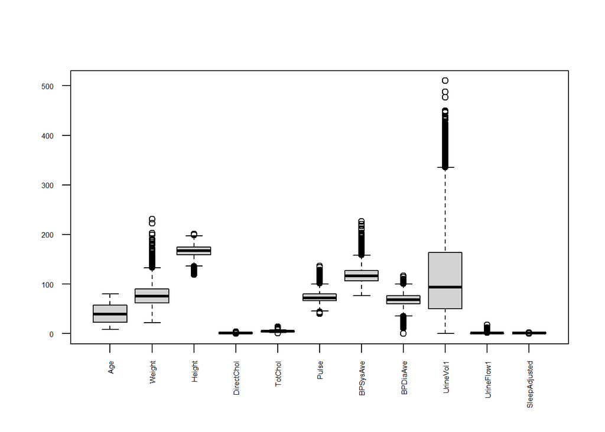

```r
numerical_data = my_data %>% dplyr::select(where(is.numeric))
boxplot(numerical_data[, sapply(numerical_data, is.numeric)],las = 2, cex.axis = 0.5)
```

```r
# 1) Identify them
identify_outliers <- function(x) {
  Q1 <- quantile(x, 0.25, na.rm = TRUE)
  Q3 <- quantile(x, 0.75, na.rm = TRUE)
  IQR_value <- Q3 - Q1
  outliers <- x < (Q1 - 1.5 * IQR_value) | x > (Q3 + 1.5 * IQR_value)
  return(outliers)
}

# Apply outlier function to each numeric column
outlier_matrix <- sapply(numerical_data[, sapply(numerical_data, is.numeric)], identify_outliers)

# Check which columns and rows have outliers
outliers_by_variable <- colSums(outlier_matrix) # Number of outliers per variable
outliers_by_variable
```

```
##           Age        Weight        Height    DirectChol       TotChol
##             0           112           111           149            89
##         Pulse      BPSysAve      BPDiaAve     UrineVol1    UrineFlow1
##           130           160           196           183           376
## SleepAdjusted
##            25
```

We can see that UrineFlow1 has many outliers so we decided to see its correlation to UrineVol1 to decide if we should keep it or not.

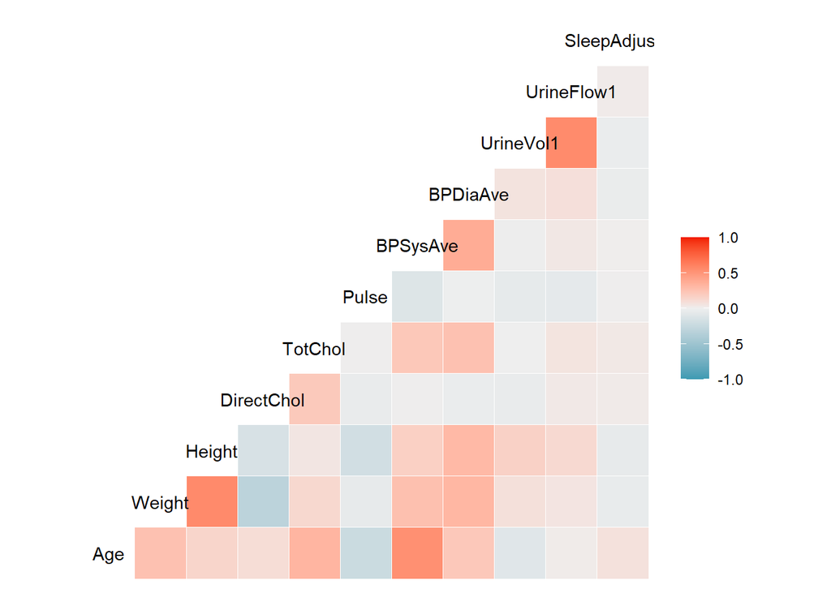

```r
ggcorr(numerical_data)
```

As this is true, we will remove UrineFlow1.Now, we will also remove all outliers.

```r
numerical_data = numerical_data %>% dplyr::select(-UrineFlow1)
outlier_matrix <- sapply(numerical_data[, sapply(numerical_data, is.numeric)], identify_outliers)
my_data = my_data %>% dplyr::select(-UrineFlow1)
cleaned_data <- my_data[!rowSums(outlier_matrix), ]
summary(cleaned_data)
```

```
##     Gender          Race1           Age             MaritalStatus
##  female:2372   Black   : 698   Min.   : 8.00   Divorced    : 352
##  male  :2319   Hispanic: 345   1st Qu.:24.00   LivePartner : 322
##                Mexican : 570   Median :39.00   Married     :2032
##                White   :2656   Mean   :40.77   NeverMarried:1618
##                Other   : 422   3rd Qu.:56.00   Separated   : 114
##                                Max.   :80.00   Widowed     : 253
##           HHIncome        Weight           Height               BMI
##  High Income  :2587   Min.   : 24.80   Min.   :136.0   NormWeight :1528
##  Low Income   : 561   1st Qu.: 63.60   1st Qu.:159.8   Obese      :1507
##  Middle Income:1543   Median : 76.30   Median :167.4   OverWeight :1478
##                       Mean   : 77.49   Mean   :167.2   UnderWeight: 178
##                       3rd Qu.: 90.30   3rd Qu.:174.9
##                       Max.   :132.70   Max.   :197.2
##    DirectChol       TotChol          Pulse           BPSysAve
##  Min.   :0.470   Min.   :2.170   Min.   : 46.00   Min.   : 78.0
##  1st Qu.:1.090   1st Qu.:4.090   1st Qu.: 64.00   1st Qu.:106.0
##  Median :1.299   Median :4.760   Median : 72.00   Median :115.0
##  Mean   :1.326   Mean   :4.794   Mean   : 72.51   Mean   :116.8
##  3rd Qu.:1.530   3rd Qu.:5.400   3rd Qu.: 80.00   3rd Qu.:126.0
##  Max.   :2.220   Max.   :7.530   Max.   :100.00   Max.   :158.0
##     BPDiaAve        UrineVol1     PhysActive Diabetes   SleepAdjusted
##  Min.   : 36.00   Min.   :  0.0   No :2003   No :4252   Min.   :0.4286
##  1st Qu.: 61.00   1st Qu.: 50.0   Yes:2688   Yes: 439   1st Qu.:0.8571
##  Median : 68.00   Median : 92.0                         Median :1.0000
##  Mean   : 67.87   Mean   :111.8                         Mean   :0.9736
##  3rd Qu.: 75.00   3rd Qu.:157.0                         3rd Qu.:1.1429
##  Max.   :100.00   Max.   :335.0                         Max.   :1.5714
```

# Visualization

1. Create histograms to show the distribution of each variable.

This allows us to see which variables are normally distributed, which are skewed, which are multimodal(have peaks in the histogram), or which have low variance.

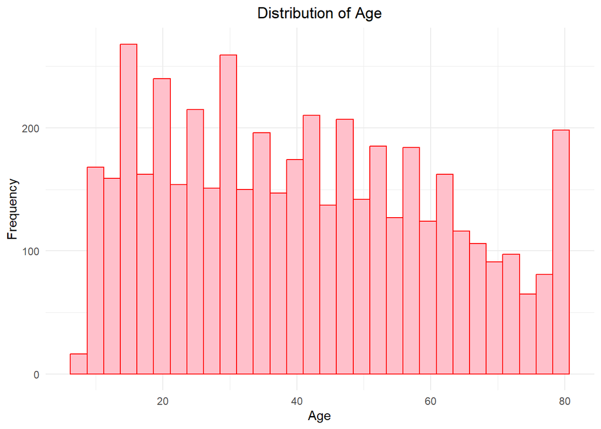

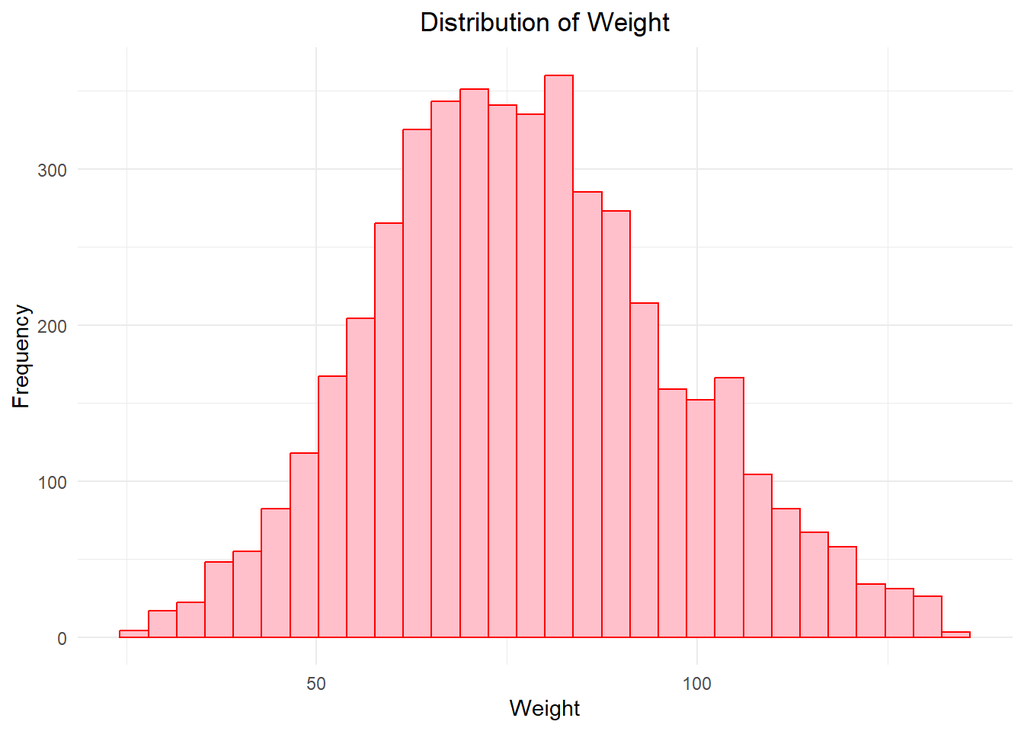

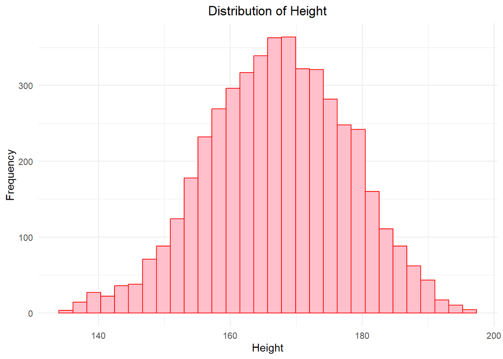

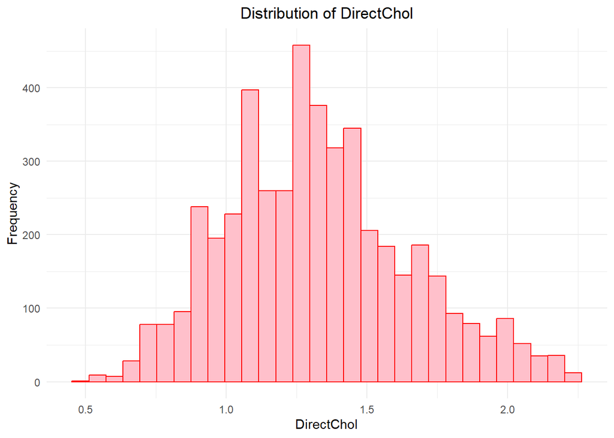

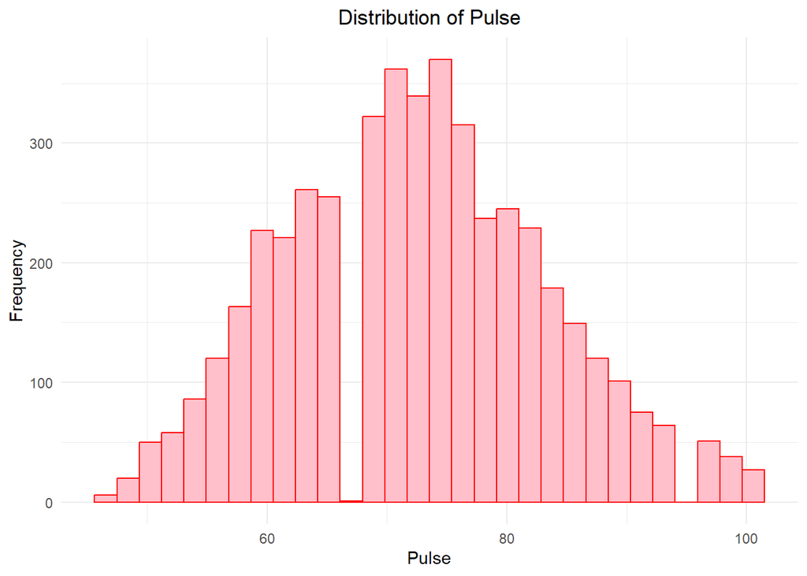

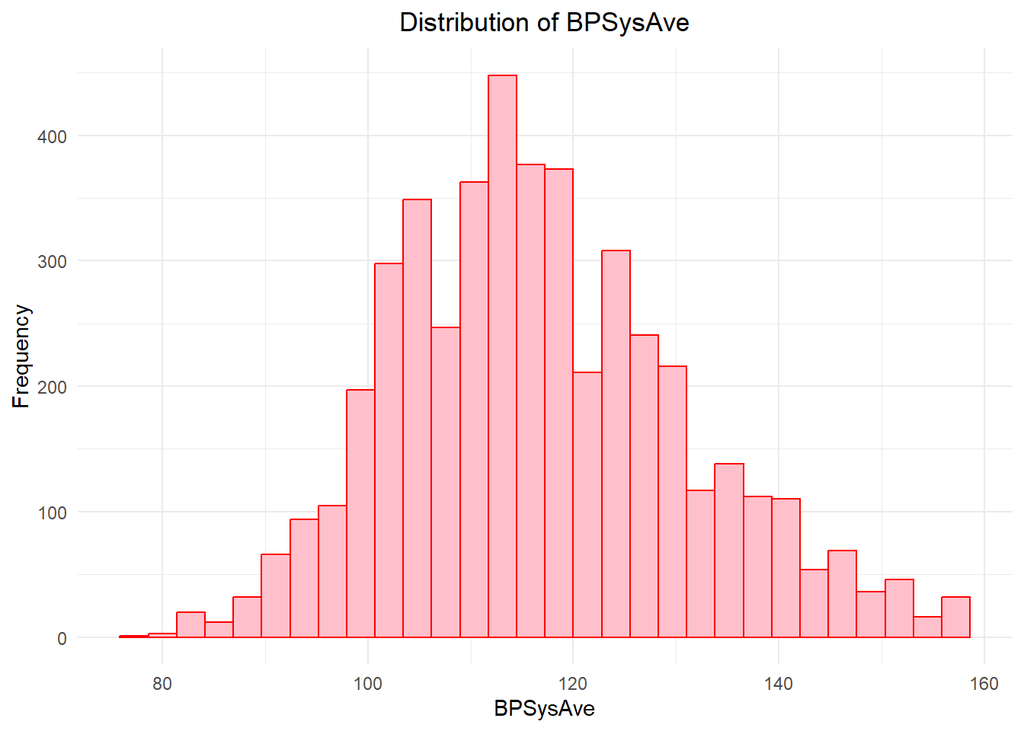

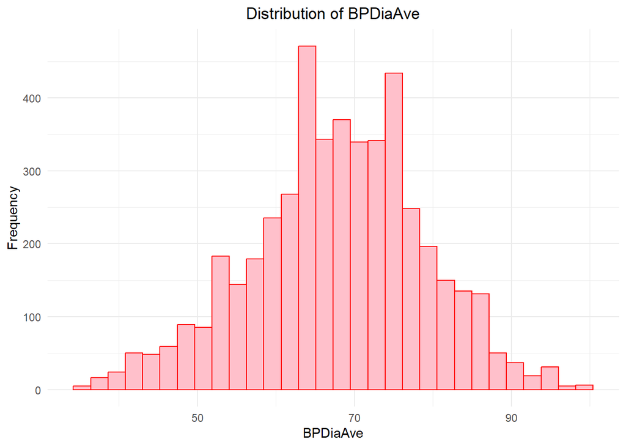

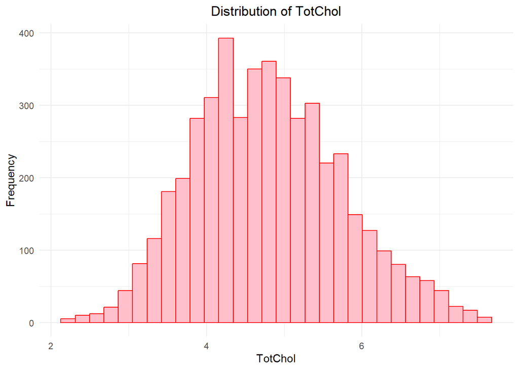

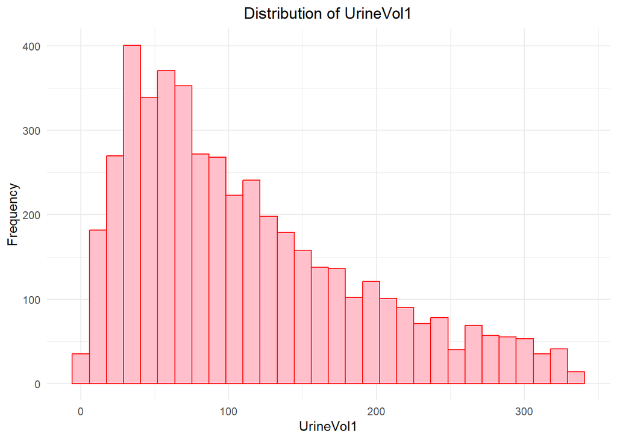

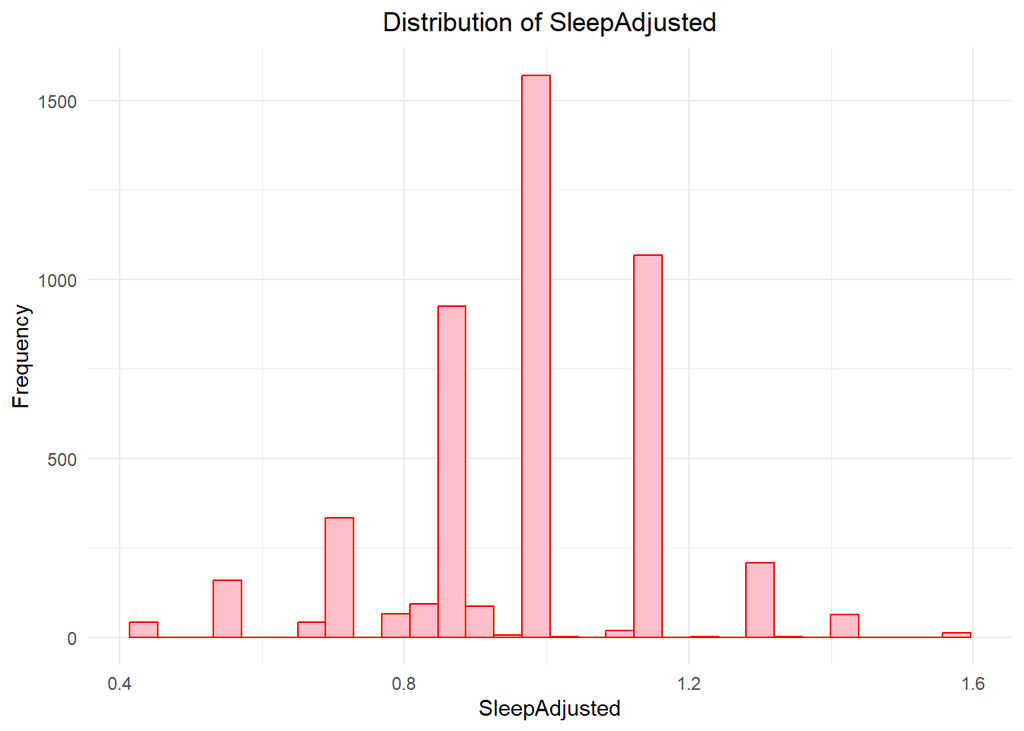

```r
numeric_vars <- c("Age", "Weight", "Height", "DirectChol", "Pulse", "BPSysAve",
                  "BPDiaAve", "TotChol", "UrineVol1", "SleepAdjusted")
for (var in numeric_vars) {
  p <- ggplot(cleaned_data, aes_string(var)) +
    geom_histogram(bins = 30, fill = "pink", color = "red") +
    theme_minimal() +
    ggtitle(paste("Distribution of", var)) +
    xlab(var) + ylab("Frequency") +
    theme(plot.title = element_text(hjust = 0.5))

  print(p)
}
```

```r
# If it gives a warning, just run that section again.
```

UrineVol1 is very skewed, which could affect some of the supervised learning models, which we will use.

# Deal with skewness.

```r
offset <- abs(min(cleaned_data$UrineVol1)) + 1
boxcox_result <- boxcox((cleaned_data$UrineVol1 + offset) ~ 1)
```

[figure not shown]

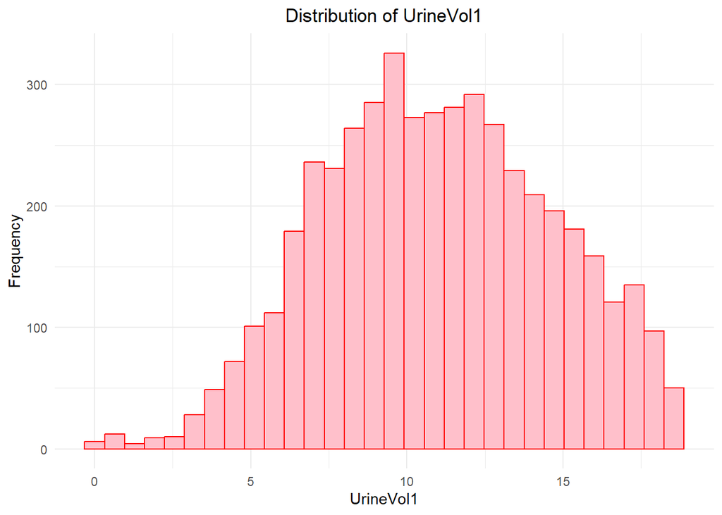

```r
lambda <- boxcox_result$x[which.max(boxcox_result$y)]
cleaned_data$UrineVol1 <- ((cleaned_data$UrineVol1 + offset)^lambda - 1) / lambda

ggplot(cleaned_data, aes_string("UrineVol1")) +
    geom_histogram(bins = 30, fill = "pink", color = "red") +
    theme_minimal() +
    ggtitle(paste("Distribution of", "UrineVol1")) +
    xlab("UrineVol1") + ylab("Frequency") +
    theme(plot.title = element_text(hjust = 0.5))
```

### Correlations between predictors

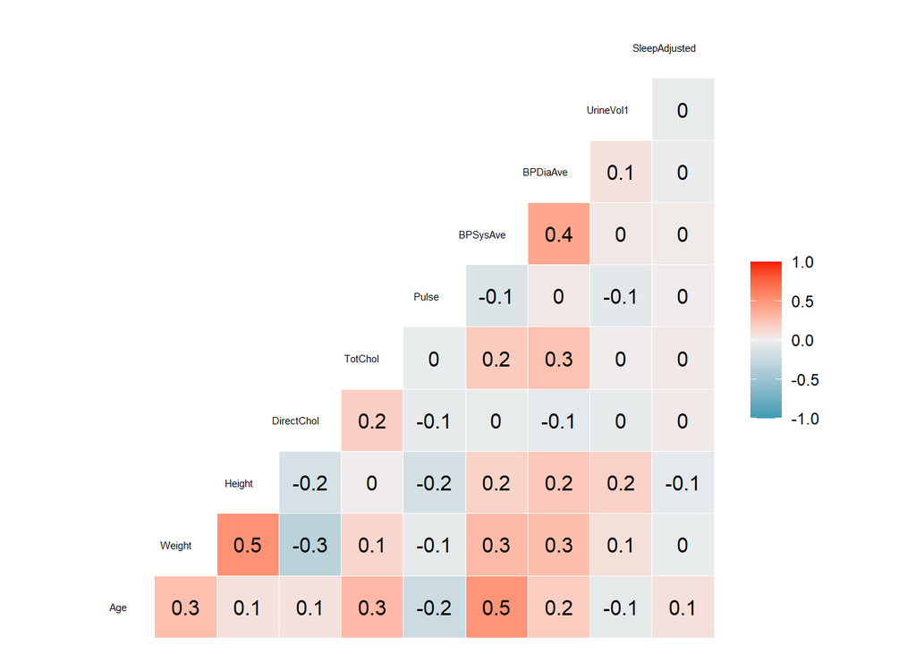

```r
ggcorr(cleaned_data[,-1],label=T,hjust=0.8,size = 2)
```

Moderate correlation

Distribution of Diabetes

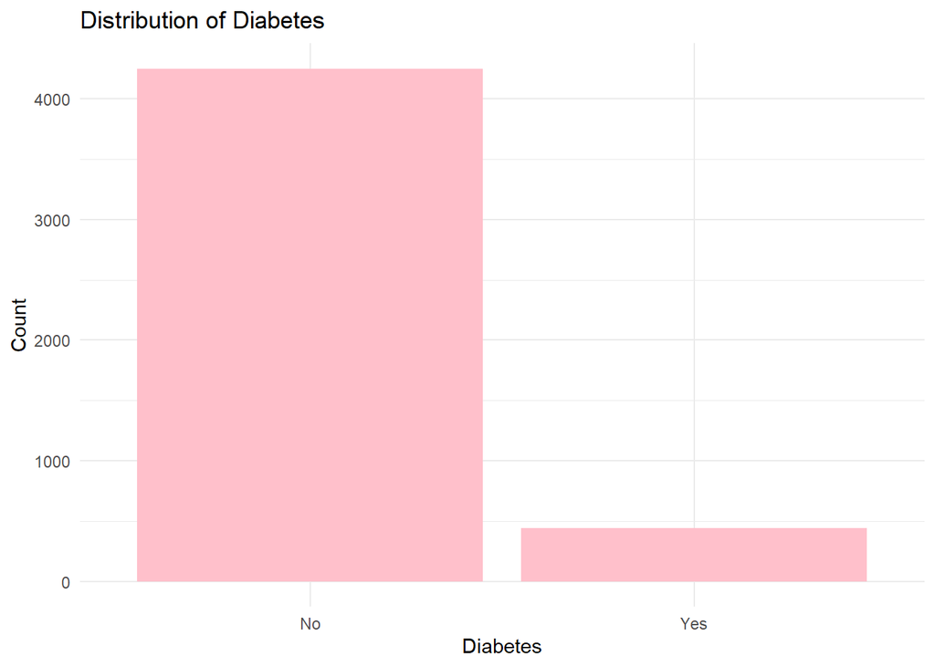

```r
ggplot(cleaned_data, aes(x = Diabetes)) +
  geom_bar(fill = "pink") +
  theme_minimal() +
  labs(title = "Distribution of Diabetes", x = "Diabetes", y = "Count")
```

This means that our dataset is unbalanced so we will need to be more careful with interpreting the results of our models and make sure that our model is not choosing wrongly just to get a better overall accuracy score.

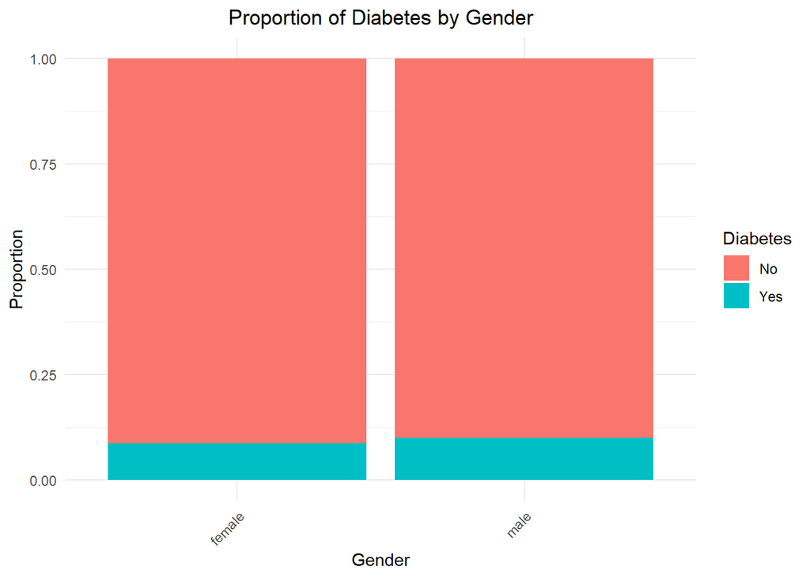

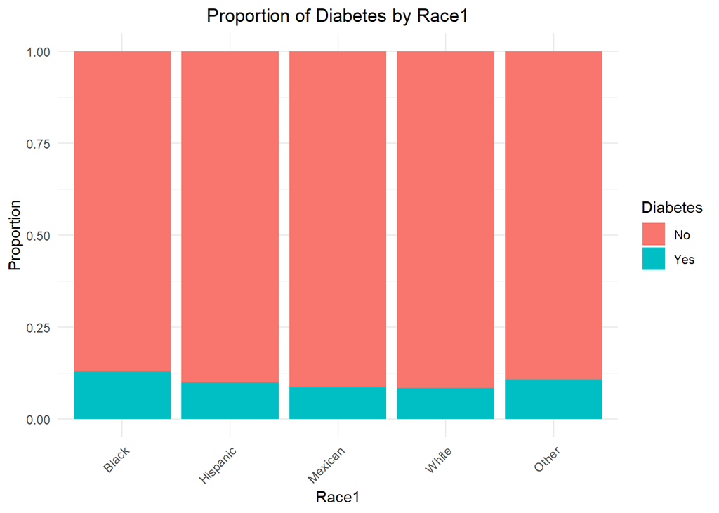

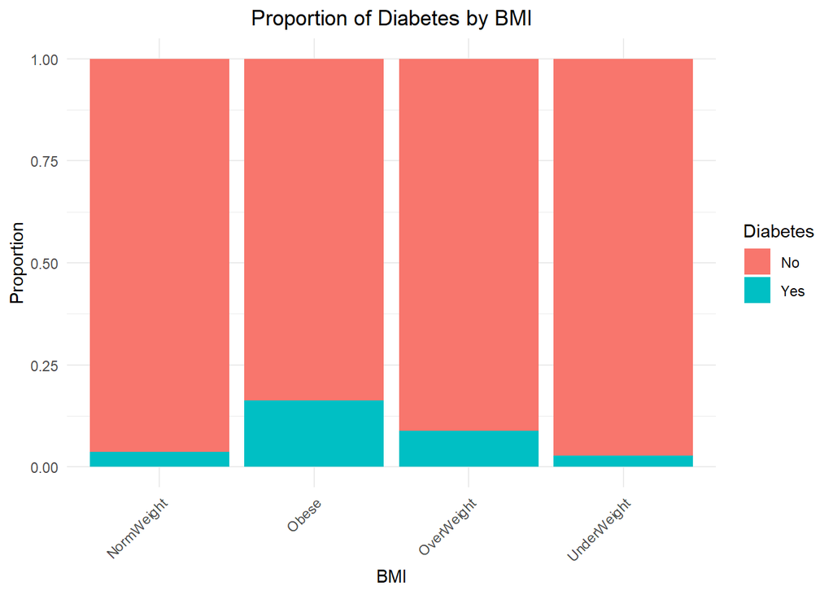

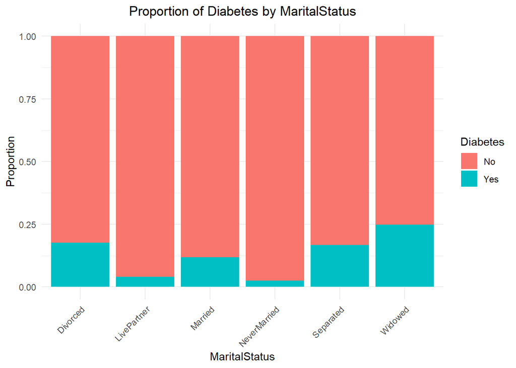

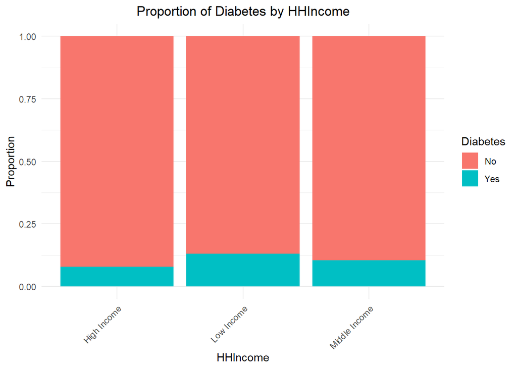

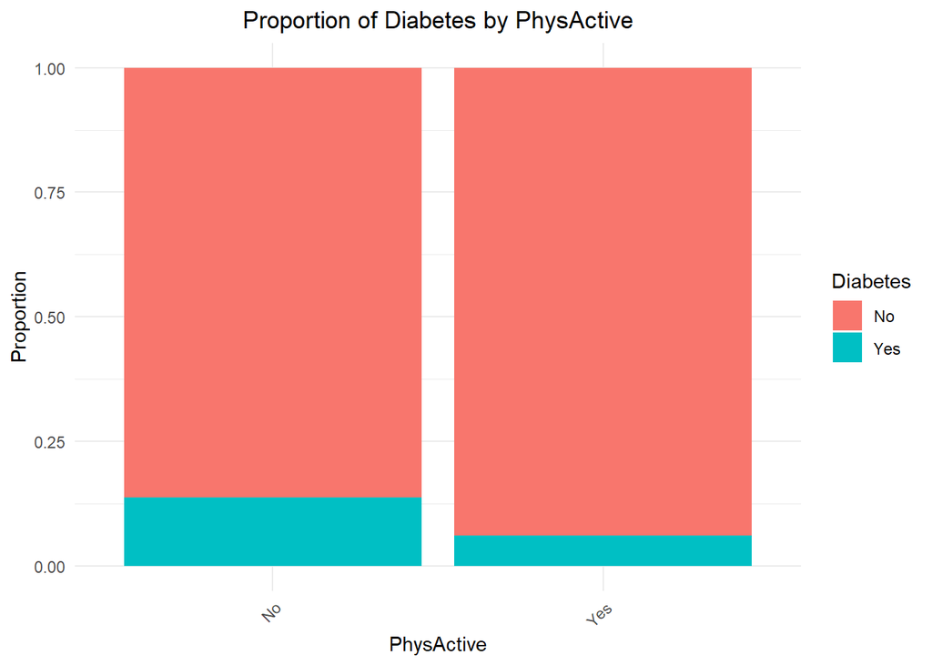

```r
numeric_vars <- c("Gender", "Race1", "BMI", "MaritalStatus", "HHIncome", "PhysActive")
for (var in numeric_vars) {
  p <- ggplot(cleaned_data, aes_string(x = var, fill = "Diabetes")) +
    geom_bar(position = "fill") +
    theme_minimal() +
    ggtitle(paste("Proportion of Diabetes by", var)) +
    xlab(var) + ylab("Proportion") +
    theme(plot.title = element_text(hjust = 0.5))+
    theme(axis.text.x = element_text(angle = 45, hjust = 1))

  print(p)
}
```

As we can see by the graphs gender doesn’t really affect the probability of a person having diabetes. From race standpoint, black people are the most likely to have diabetes, but the proportions for the other races is not that different. The graph shows that obese and over weight people are more likely to be diabetic than normal or under weight people. For marital status, 25% of widowed people and roughly 20% of divorced and separated people have diabetes. In the never married category(which includes mainly young people), there are less than 5% people with diabetes. Income doesn’t really show that any group has a particularly larger probability to have diabetes, but the people with low income are more likely to have it. Lastly, people that are not physically active are also more likely to be diabetic then those that are physically active.

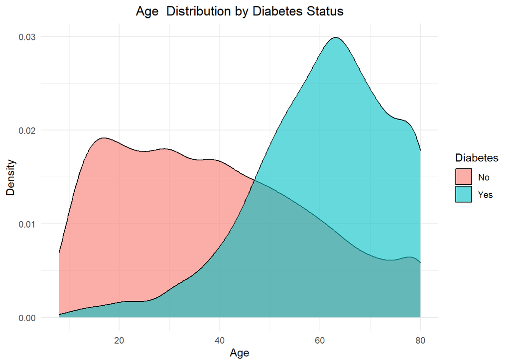

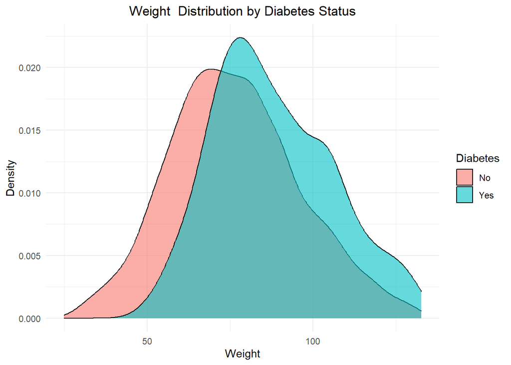

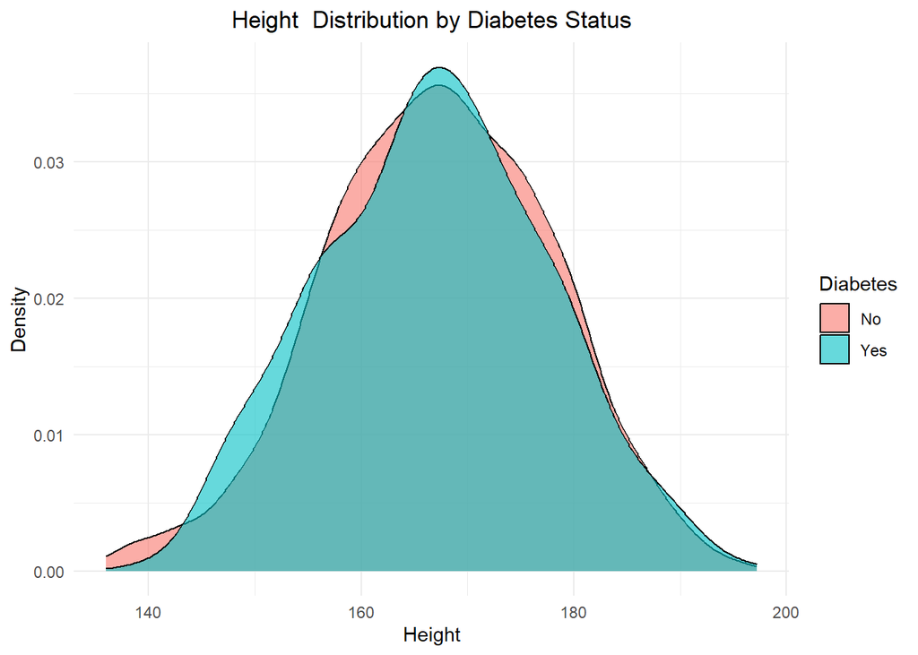

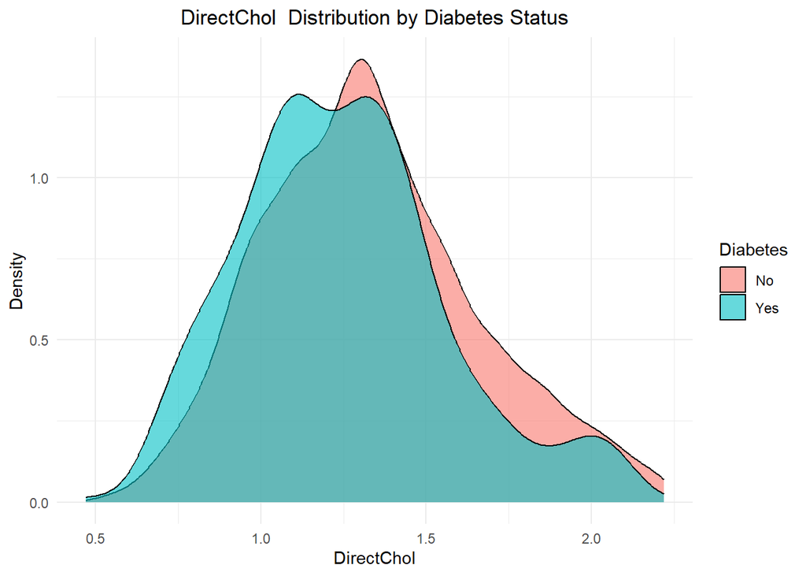

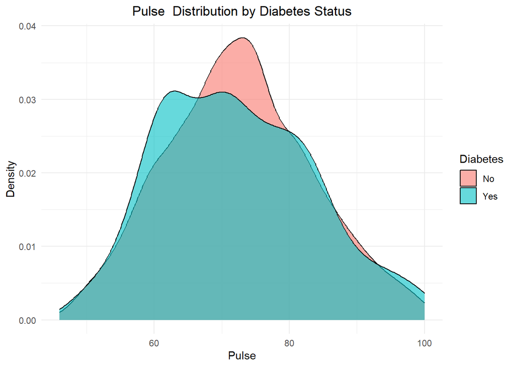

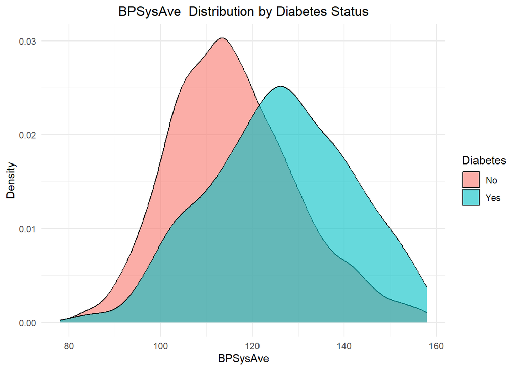

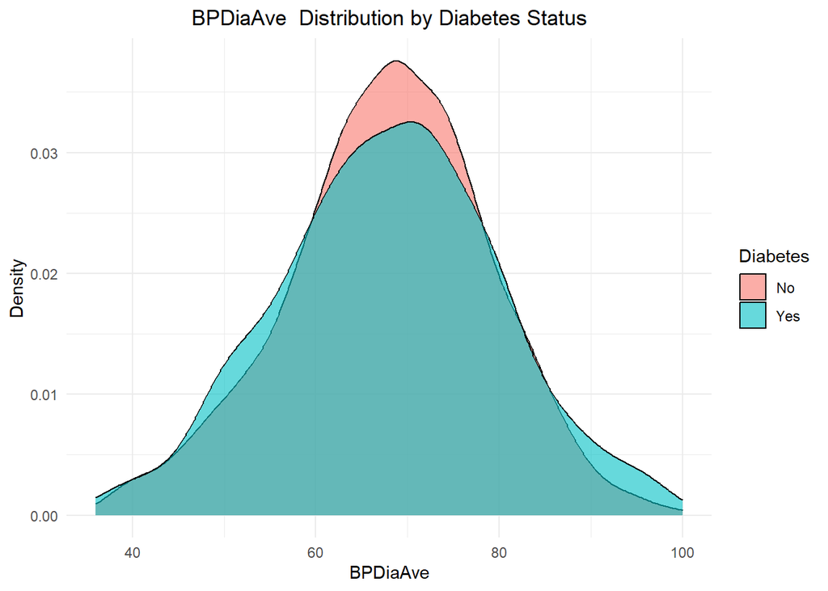

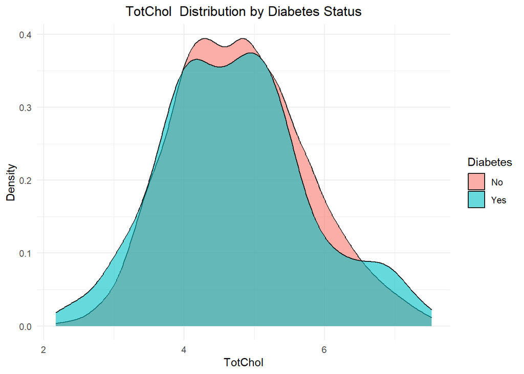

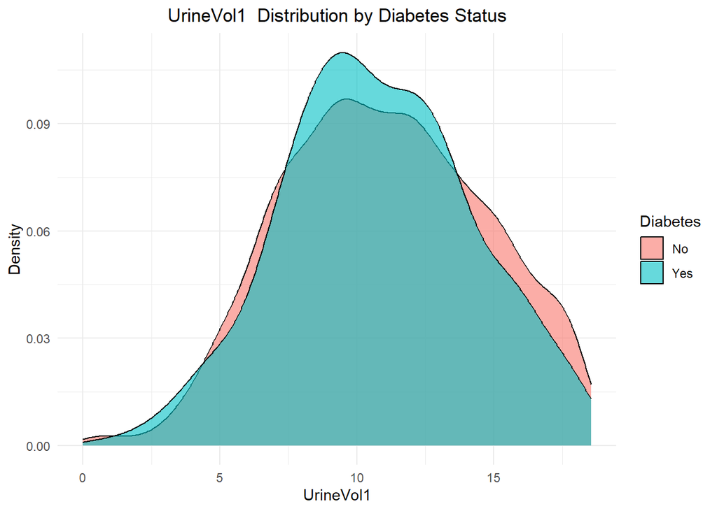

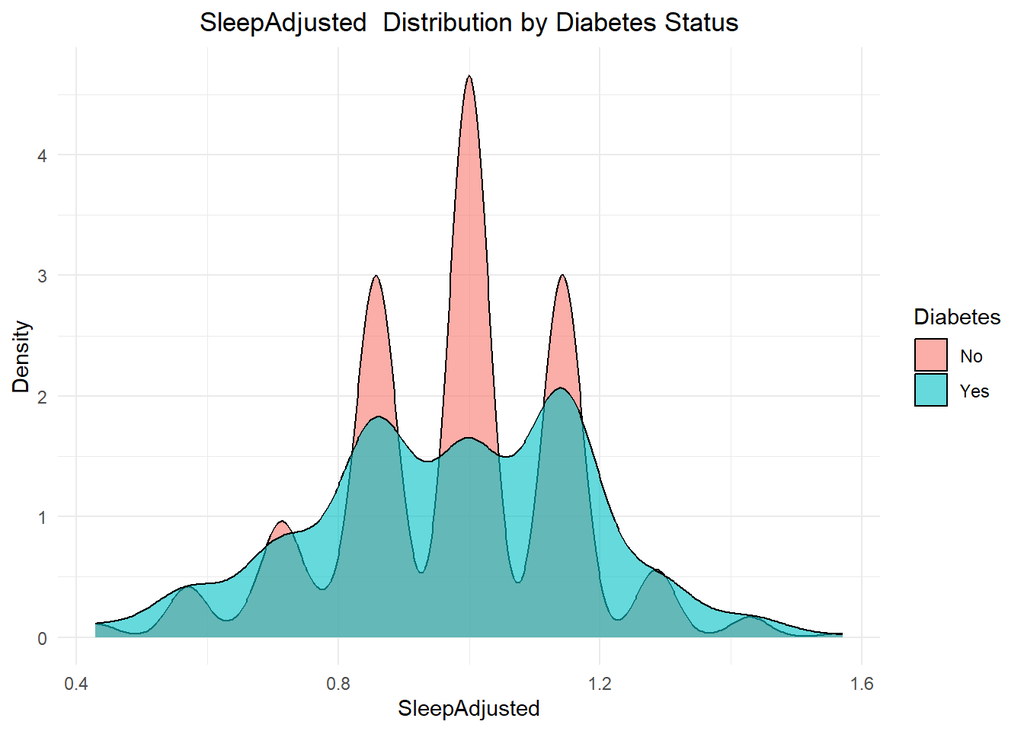

```r
numeric_vars <- c("Age", "Weight", "Height", "DirectChol", "Pulse", "BPSysAve",
                  "BPDiaAve", "TotChol", "UrineVol1", "SleepAdjusted")
for (var in numeric_vars) {
  p <- ggplot(cleaned_data, aes_string(x = var, fill = "Diabetes")) +
    geom_density(alpha = 0.6) +
    theme_minimal() +
    ggtitle(paste(var, " Distribution by Diabetes Status")) +
    xlab(var) + ylab("Density") +
    theme(plot.title = element_text(hjust = 0.5))

  print(p)
}
```

From these graphs we can see that older people, people that weight more or people that have higher BPSysAve are more likely to be diabetic. Otherwise, the other variables don’t really show a particular impact on the diagnosis.

# Normalization of variables:

```r
normalize_z <- function(x) {(x - mean(x, na.rm = TRUE)) / sd(x, na.rm = TRUE)}
normalized_cleaned_data <- cleaned_data %>%
  mutate(across(where(is.numeric), normalize_z))
```

# Splitting the data into training(40%) and testing(60%) data

```r
set.seed(10)
split <- createDataPartition(normalized_cleaned_data$Diabetes, p = 0.4, list = FALSE)
training_data <- normalized_cleaned_data[ split,]
testing_data <- normalized_cleaned_data[-split,]
nrow(training_data)
```

```
## [1] 1877
```

```r
nrow(testing_data)
```

```
## [1] 2814
```

```r
table(training_data$Diabetes)/length(training_data$Diabetes)
```

```
##
##         No        Yes
## 0.90623335 0.09376665
```

As we can see the dataset is very unbalanced with roughly 9.4% of the samples being diabetic and 90.6% not being diabetic.

# Bayes Classifiers

## Linear discriminant analysis

```r
lda.model <- lda(Diabetes ~ ., data=training_data)
lda.model
```

```
## Call:
## lda(Diabetes ~ ., data = training_data)
##
## Prior probabilities of groups:
##         No        Yes
## 0.90623335 0.09376665
##
## Group means:
##     Gendermale Race1Hispanic Race1Mexican Race1White Race1Other         Age
## No   0.4961787    0.07642563    0.1128748  0.5831864 0.08348031 -0.09064417
## Yes  0.5056818    0.09090909    0.1136364  0.4318182 0.11931818  1.02654693
##     MaritalStatusLivePartner MaritalStatusMarried MaritalStatusNeverMarried
## No                0.07407407            0.4215168                0.37037037
## Yes               0.02272727            0.5454545                0.09090909
##     MaritalStatusSeparated MaritalStatusWidowed HHIncomeLow Income
## No              0.02704292           0.04291593          0.1293357
## Yes             0.04545455           0.15340909          0.1931818
##     HHIncomeMiddle Income      Weight      Height  BMIObese BMIOverWeight
## No              0.3086420 -0.03716055  0.01126068 0.2998236     0.3221634
## Yes             0.3806818  0.50653033 -0.14611311 0.5625000     0.3011364
##     BMIUnderWeight   DirectChol     TotChol       Pulse    BPSysAve   BPDiaAve
## No      0.04115226  0.006574094  0.02122979  0.01685636 -0.06783249 0.04553863
## Yes     0.01136364 -0.170233632 -0.03055248 -0.02472471  0.68341566 0.06345590
##         UrineVol1 PhysActiveYes SleepAdjusted
## No  -0.0006630749     0.5961199  -0.001406884
## Yes -0.1361739316     0.3352273  -0.053219044
##
## Coefficients of linear discriminants:
##                                   LD1
## Gendermale                 0.26976975
## Race1Hispanic             -0.38875517
## Race1Mexican              -0.40776775
## Race1White                -0.73303335
## Race1Other                -0.01848324
## Age                        0.85077172
## MaritalStatusLivePartner  -0.73264836
## MaritalStatusMarried      -0.44675823
## MaritalStatusNeverMarried -0.36195543
## MaritalStatusSeparated    -0.32679861
## MaritalStatusWidowed      -0.32767415
## HHIncomeLow Income         0.20628491
## HHIncomeMiddle Income      0.13631144
## Weight                     0.42342917
## Height                    -0.40030131
## BMIObese                  -0.10144078
## BMIOverWeight             -0.16356673
## BMIUnderWeight             0.18634978
## DirectChol                -0.07477950
## TotChol                   -0.31311060
## Pulse                      0.14202296
## BPSysAve                   0.24311293
## BPDiaAve                  -0.23377025
## UrineVol1                 -0.01989964
## PhysActiveYes             -0.10179875
## SleepAdjusted             -0.09794522
```

This shows that the most important variables(variables with large coefficients) for our prediction are Age, Race1White, MaritalStatusLivePartner. Age’s coefficient is positive, which means that it is associated with a higher chance of being in the diabetes positive group. Older people are more likely to be diabetic. People that are white or have a marital status of LivePartner are less likely to be diabetic.

Overall the most important predictors are Age, Race, Marital Status, while moderate predictors are Weight, Height, HHIncome, BPSysAve, BPDiaAve. The other don’t contribute as much.

```r
probability_lda = predict(lda.model, newdata=testing_data)$posterior
head(probability_lda)
```

```
##          No         Yes
## 1 0.9910682 0.008931772
## 2 0.9404091 0.059590859
## 3 0.8332070 0.166793046
## 4 0.9547302 0.045269842
## 5 0.9963893 0.003610738
## 6 0.9249903 0.075009688
```

```r
prediction_lda = predict(lda.model, newdata=testing_data)$class
head(prediction_lda)
```

```
## [1] No No No No No No
## Levels: No Yes
```

```r
print(confusionMatrix(prediction_lda, testing_data$Diabetes)$table)
```

```
##           Reference
## Prediction   No  Yes
##        No  2463  198
##        Yes   88   65
```

```r
print(confusionMatrix(prediction_lda, testing_data$Diabetes)$overall[1])
```

```
##  Accuracy
## 0.8983653
```

```r
print(confusionMatrix(prediction_lda, testing_data$Diabetes)$byClass["Specificity"])
```

```
## Specificity
##   0.2471483
```

```r
print(confusionMatrix(prediction_lda, testing_data$Diabetes)$byClass["Balanced Accuracy"])
```

```
## Balanced Accuracy
##          0.606326
```

The accuracy looks good, however the specificity and balanced accuracy prove otherwise. Interpretation of specificity: The model correctly identifies 24.7% of individuals with diabetes (“Yes” cases). The model misses a substantial number of true positive cases. Interpretation of balanced accuracy: The model is not the best and there is room for improvement in balancing the classification for the classes.

## Quadratic discriminant analysis

```r
qda.model <- qda(Diabetes ~ ., data=training_data)
qda.model
```

```
## Call:
## qda(Diabetes ~ ., data = training_data)
##
## Prior probabilities of groups:
##         No        Yes
## 0.90623335 0.09376665
##
## Group means:
##     Gendermale Race1Hispanic Race1Mexican Race1White Race1Other         Age
## No   0.4961787    0.07642563    0.1128748  0.5831864 0.08348031 -0.09064417
## Yes  0.5056818    0.09090909    0.1136364  0.4318182 0.11931818  1.02654693
##     MaritalStatusLivePartner MaritalStatusMarried MaritalStatusNeverMarried
## No                0.07407407            0.4215168                0.37037037
## Yes               0.02272727            0.5454545                0.09090909
##     MaritalStatusSeparated MaritalStatusWidowed HHIncomeLow Income
## No              0.02704292           0.04291593          0.1293357
## Yes             0.04545455           0.15340909          0.1931818
##     HHIncomeMiddle Income      Weight      Height  BMIObese BMIOverWeight
## No              0.3086420 -0.03716055  0.01126068 0.2998236     0.3221634
## Yes             0.3806818  0.50653033 -0.14611311 0.5625000     0.3011364
##     BMIUnderWeight   DirectChol     TotChol       Pulse    BPSysAve   BPDiaAve
## No      0.04115226  0.006574094  0.02122979  0.01685636 -0.06783249 0.04553863
## Yes     0.01136364 -0.170233632 -0.03055248 -0.02472471  0.68341566 0.06345590
##         UrineVol1 PhysActiveYes SleepAdjusted
## No  -0.0006630749     0.5961199  -0.001406884
## Yes -0.1361739316     0.3352273  -0.053219044
```

The most important variables are Age(big difference between “Yes” and “No” groups), BMIObese (significant difference in the BMI categories between the two groups(Yes and No) suggests that obesity is important factor), Race variables(Differences in race categories can be helpful to decide between the two classes), and Income(different distributions for the two groups, which indicates that financial factors could be important).

Performance:

```r
prediction_qda = predict(qda.model, newdata=testing_data)$class
print(confusionMatrix(prediction_qda, testing_data$Diabetes)$table)
```

```
##           Reference
## Prediction   No  Yes
##        No  2194  129
##        Yes  357  134
```

```r
print(confusionMatrix(prediction_qda, testing_data$Diabetes)$overall[1])
```

```
##  Accuracy
## 0.8272921
```

```r
print(confusionMatrix(prediction_qda, testing_data$Diabetes)$byClass["Specificity"])
```

```
## Specificity
##   0.5095057
```

```r
print(confusionMatrix(prediction_qda, testing_data$Diabetes)$byClass["Balanced Accuracy"])
```

```
## Balanced Accuracy
##         0.6847803
```

The accuracy is not bad.

Interpretation of specificity: The model correctly identifies 50.9% of individuals with diabetes (“Yes” cases). The model misses a substantial number of true positive cases. Interpretation of balanced accuracy: The model is not the best and there is room for improvement in balancing the classification for the classes.

Between the LDA and QDA model, the QDA is better as while its overall accuracy is less, its balanced accuracy is higher and its specificity is higher, which indicate that this model is less biased than the previous one.